# More accessible data science

*Compute! Paris 2026*

## About

*Joseph*

ysunflower.com

**Consulting / open source**:

data(viz), Typst, accessibility

## Digital accessibility

> *Ensuring that people with disabilities can **perceive**, **understand**, **navigate**, and **interact** with digital content, services, software, and more.*

## Digital accessibility

**Not just a good practice, but a legal requirement!**

- **1990** — Americans with Disabilities Act (US)
- **2005** — French Disability Law (France)
- **2016** — Web Accessibility Directive (EU)
- **2025** — European Accessibility Act (EU, applicable since June)

> Non-compliance can result in lawsuits, financial penalties, or market restrictions.

## Digital accessibility

- Less than **1% of PDFs** meet accessibility standards
- Less than **4.1% of web pages** meet accessibility standards

### References

- *PDF Trends 2026: the production, structure, and accessibility of 20,000,000 PDFs*, **PDF Association**
- *WebAIM Million: The 2026 report on the accessibility of the top 1,000,000 home pages*, **WebAIM**

## Accessibility and data science

**Tools we use**: IDEs, notebooks, spreadsheets, BI tools, documentation

[figure not shown]

**Outputs we produce**: dashboards, charts, PDFs, web reports, slides

[figure not shown]

## Problem

Accessibility rarely happens by default, which means we need to **be intentional** about ensuring it.

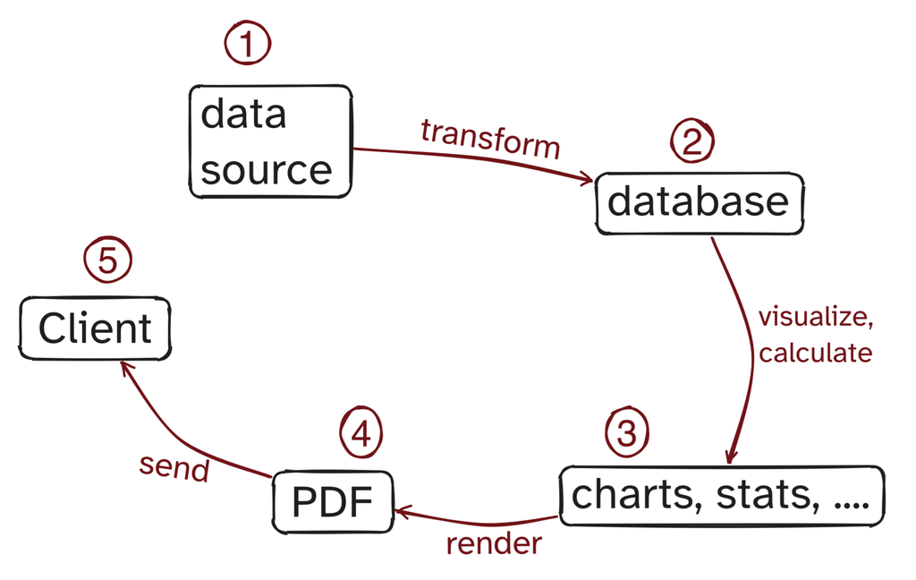

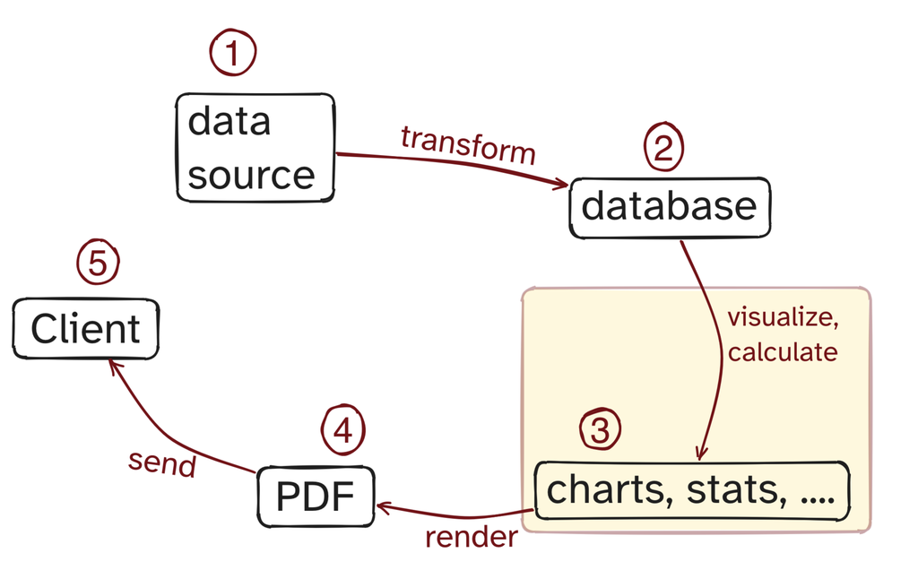

# Data visualization

## Color contrast

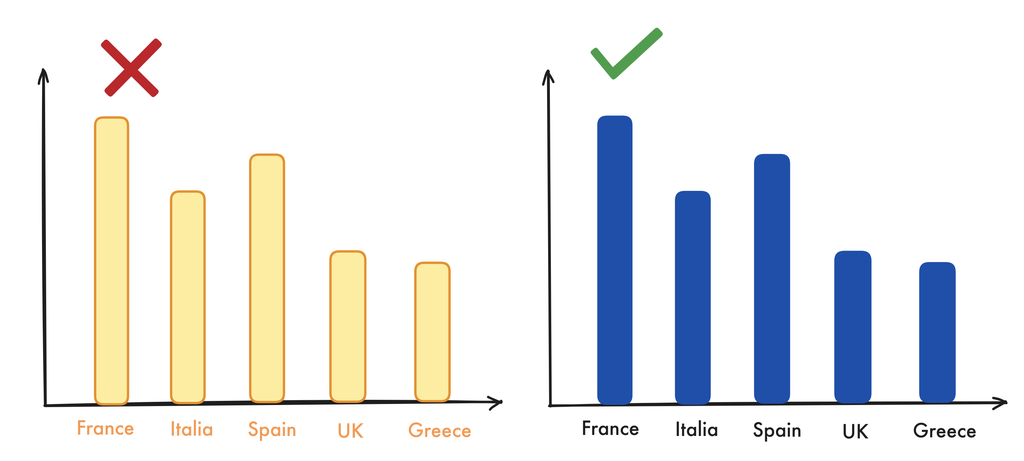

Yellow bars on white: **1.18:1**

Blue bars on white: **7.63:1**

## Color contrast

Sample text

2.1:1

Sample text

4.48:1

Sample text

7:1

Sample text

21:1

## Colorblindness

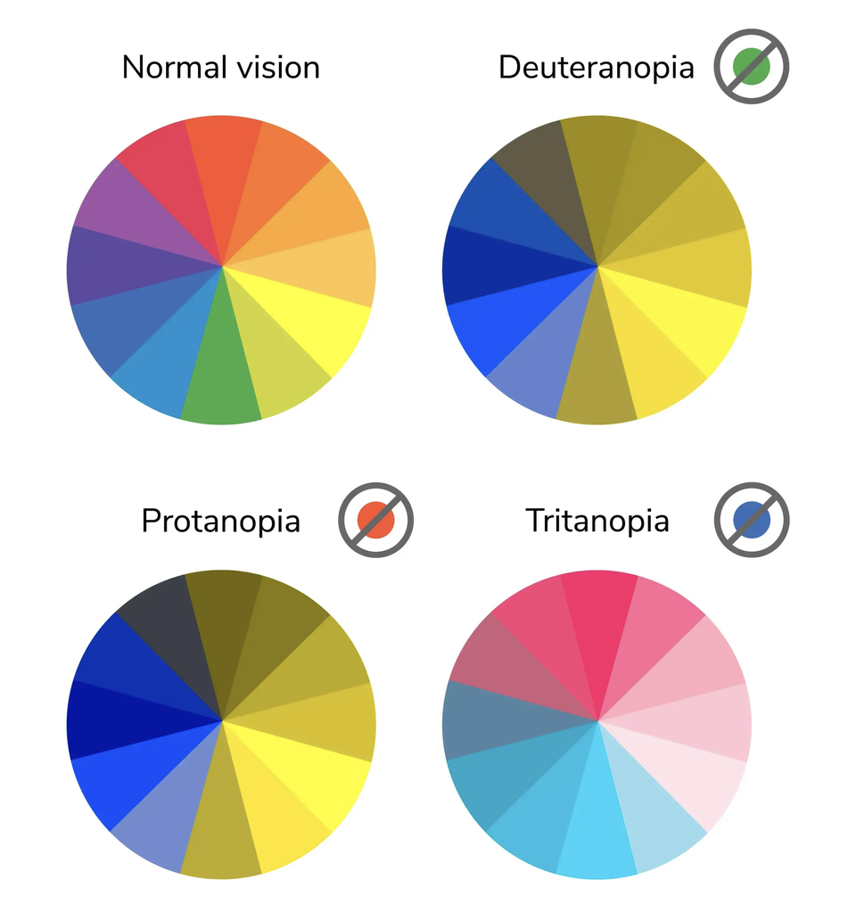

## Colorblind-friendly palette

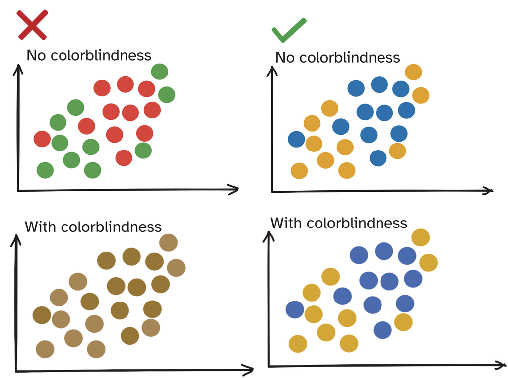

## Colorblind-friendly palette + double encoding

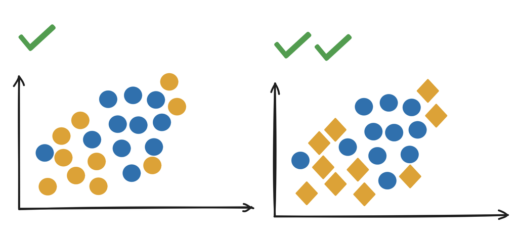

## Fonts

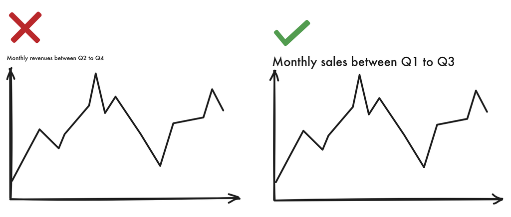

## Fonts

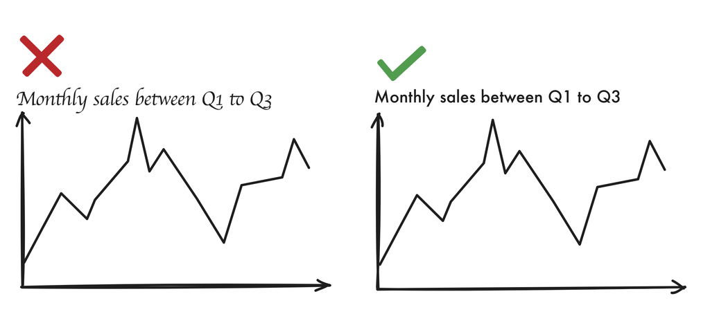

## Fonts

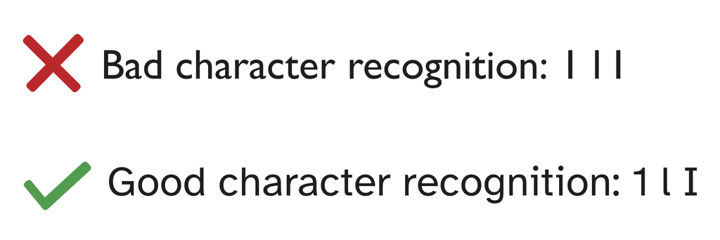

Atkinson Hyperlegible

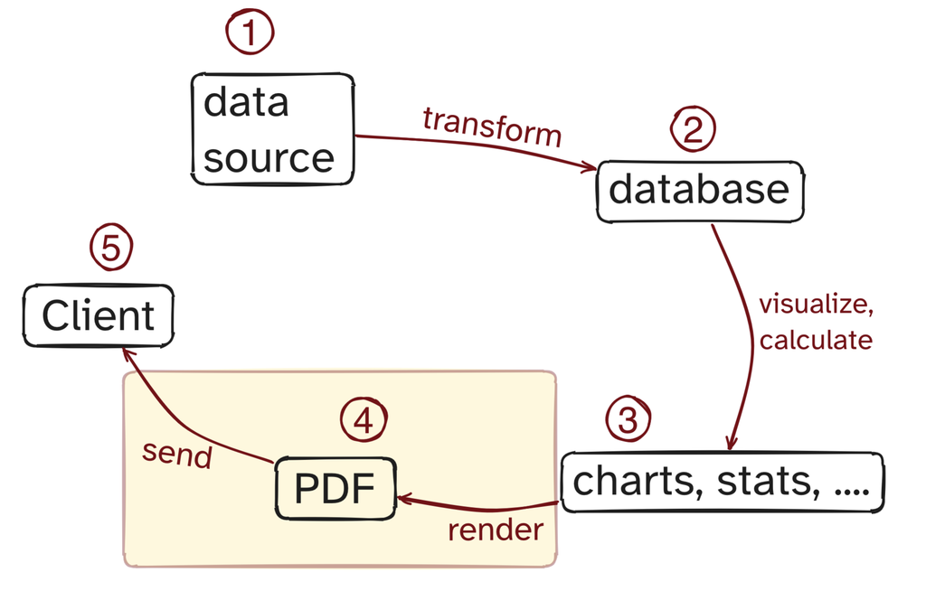

# **Documents & reports**: PDF, HTML, Markdown, Word…

[figure not shown]

## Semantic structure

❌ Don’t:

```markdown
# Title

### A subtitle

Lorem ipsum dolor sit amet, consectetur adipiscing elit, sed do
```

✅ Do:

```markdown
# Title

## A subtitle

Lorem ipsum dolor sit amet, consectetur adipiscing elit, sed do
```

## Alternative text

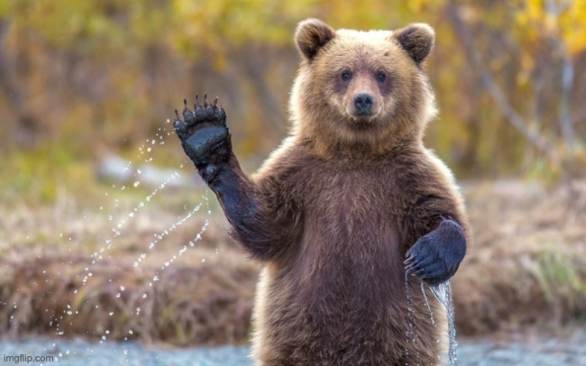

> *“A brown bear standing upright in water, waving a paw.”*

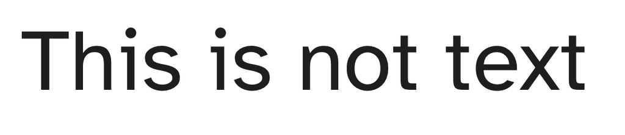

This is text

### This is a heading

This is not a heading

## Dashboards, interactive charts, web apps

[video not shown]

# What’s next?

## What’s next?

Accessibility can be viewed as an **engineering problem**!

- automate accessibility validation
- good vs. great accessibility

## What’s next?

Accessibility audit!

PDF: veraPDF/veraPDF-library  
HTML: dequelabs/axe-core  
Markdown: DavidAnson/markdownlint

## Colorblindness simulators

R: clauswilke/colorblindr  
Python: y-sunflower/realcolor

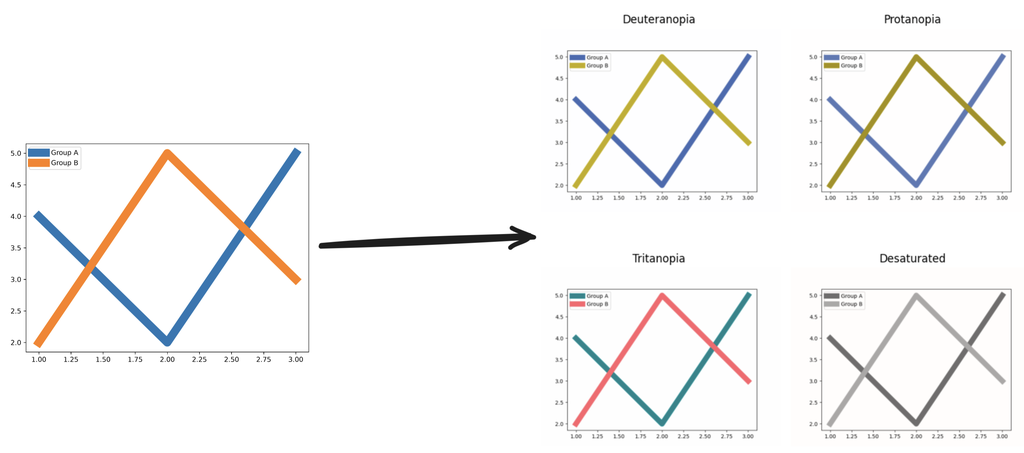

## Alt text generators

R: y-sunflower/ggalttext  
Python: make4all/matplotalt

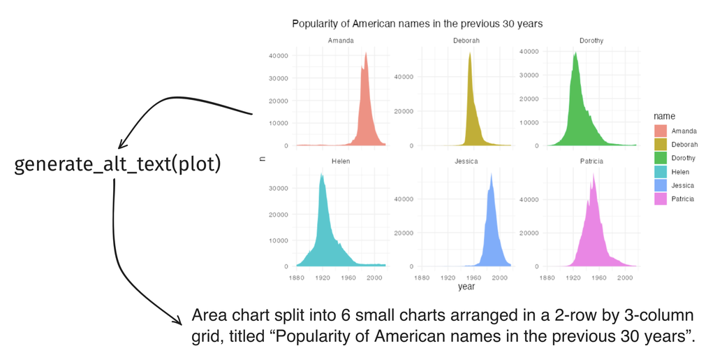

## Screen reader testing

Windows: nvaccess/nvda  
Linux: GNOME/orca  
macOS / iOS: [VoiceOver](https://www.apple.com/accessibility/vision/) (built-in)  
Android: [TalkBack](https://github.com/google/talkback) (built-in)

**Passing an accessibility audit doesn’t guarantee accessibility!**

## AI & accessibility

[figure not shown]

Read only skill: y-sunflower/data-science-accessibility

## Thanks!

[figure not shown]

Slides

[figure not shown]